# Movie Magic?

How successful is a movie? Is it the money it makes, or how much audiences enjoy it? That’s what I want to explore. Using data, I hope to uncover patterns that reveal different kinds of success — whether financial, critical, or something in between. Rather than predicting outcomes, this project uses clustering, an exploratory technique in data mining that groups similar movies based on shared characteristics. The goal isn’t to say what will make a future movie successful, but to see how existing movies naturally group together when we look at their budgets, revenues, and ratings. Through these patterns, I hope to gain insight into the different “types” of success films can achieve.

# The Movies

Banik, R. (n.d.). The Movies Dataset [Data set]. Kaggle. https://www.kaggle.com/datasets/rounakbanik/the-movies-dataset

The dataset titled The Movies Dataset (hosted on Kaggle) contains metadata for over 45,000 movies — specifically, films listed in the full MovieLens 20M Dataset collection. It also includes approximately 26 million ratings from more than 270,000 users.

The “movies_metadata.csv” file includes features like budget, revenue, genres, production companies/countries, original language, release date, etc. The “ratings_small.csv” or ratings file captures user-movie ratings — userId, movieId, rating, timestamp.

The dataset covers movies released on or before July 2017.

```python
import pandas as pd
import matplotlib.pyplot as plt
import numpy as np
from sklearn.preprocessing import StandardScaler
from sklearn.cluster import KMeans
from sklearn.decomposition import PCA
import seaborn as sns
```

# Casting Call

Clustering is an unsupervised machine learning technique used to group similar items together based on their characteristics. Unlike supervised learning, clustering does not rely on labeled outcomes. Instead, the algorithm looks for patterns in the data and organizes observations into groups—called clusters—where items in the same cluster are more similar to each other than to items in other clusters.

In this project, clustering is useful because we are trying to understand what makes a movie “successful” without defining success beforehand. We are letting the data reveal natural groupings based on patterns in budget, revenue, and audience ratings.

To begin, I’ll import both datasets into my environment and perform an initial exploration—checking the number of rows and columns, data types, missing values, and a few sample records. This will help determine which features are relevant for clustering and which can be safely dropped.

```python
movies = pd.read_csv('../data/movies_metadata.csv', low_memory=False)
ratings = pd.read_csv('../data/ratings.csv')

print("Movies Metadata Info:")
print(movies.info())
print("\nRatings Info:")
print(ratings.info())

print("\nMovies Metadata Sample:")
display(movies.head())

print("\nRatings Sample:")
display(ratings.head())

movies.columns
```

```
Movies Metadata Info:
<class 'pandas.core.frame.DataFrame'>
RangeIndex: 45466 entries, 0 to 45465
Data columns (total 24 columns):
 #   Column                 Non-Null Count  Dtype
---  ------                 --------------  -----
 0   adult                  45466 non-null  object
 1   belongs_to_collection  4494 non-null   object
 2   budget                 45466 non-null  object
 3   genres                 45466 non-null  object
 4   homepage               7782 non-null   object
 5   id                     45466 non-null  object
 6   imdb_id                45449 non-null  object
 7   original_language      45455 non-null  object
 8   original_title         45466 non-null  object
 9   overview               44512 non-null  object
 10  popularity             45461 non-null  object
 11  poster_path            45080 non-null  object
 12  production_companies   45463 non-null  object
 13  production_countries   45463 non-null  object
 14  release_date           45379 non-null  object
 15  revenue                45460 non-null  float64
 16  runtime                45203 non-null  float64
 17  spoken_languages       45460 non-null  object
 18  status                 45379 non-null  object
 19  tagline                20412 non-null  object
 20  title                  45460 non-null  object
 21  video                  45460 non-null  object
 22  vote_average           45460 non-null  float64
 23  vote_count             45460 non-null  float64
dtypes: float64(4), object(20)
memory usage: 8.3+ MB
None

Ratings Info:
<class 'pandas.core.frame.DataFrame'>
RangeIndex: 26024289 entries, 0 to 26024288
Data columns (total 4 columns):
 #   Column     Dtype
---  ------     -----
 0   userId     int64
 1   movieId    int64
 2   rating     float64
 3   timestamp  int64
dtypes: float64(1), int64(3)
memory usage: 794.2 MB
None

Movies Metadata Sample:
```

|  | adult | belongs_to_collection | budget | genres | homepage | id | imdb_id | original_language | original_title | overview | ... | release_date | revenue | runtime | spoken_languages | status | tagline | title | video | vote_average | vote_count |
| --- | --- | --- | --- | --- | --- | --- | --- | --- | --- | --- | --- | --- | --- | --- | --- | --- | --- | --- | --- | --- | --- |
| 0 | False | {'id': 10194, 'name': 'Toy Story Collection', ... | 30000000 | [{'id': 16, 'name': 'Animation'}, {'id': 35, '... | http://toystory.disney.com/toy-story | 862 | tt0114709 | en | Toy Story | Led by Woody, Andy's toys live happily in his ... | ... | 1995-10-30 | 373554033.0 | 81.0 | [{'iso_639_1': 'en', 'name': 'English'}] | Released | NaN | Toy Story | False | 7.7 | 5415.0 |
| 1 | False | NaN | 65000000 | [{'id': 12, 'name': 'Adventure'}, {'id': 14, '... | NaN | 8844 | tt0113497 | en | Jumanji | When siblings Judy and Peter discover an encha... | ... | 1995-12-15 | 262797249.0 | 104.0 | [{'iso_639_1': 'en', 'name': 'English'}, {'iso... | Released | Roll the dice and unleash the excitement! | Jumanji | False | 6.9 | 2413.0 |
| 2 | False | {'id': 119050, 'name': 'Grumpy Old Men Collect... | 0 | [{'id': 10749, 'name': 'Romance'}, {'id': 35, ... | NaN | 15602 | tt0113228 | en | Grumpier Old Men | A family wedding reignites the ancient feud be... | ... | 1995-12-22 | 0.0 | 101.0 | [{'iso_639_1': 'en', 'name': 'English'}] | Released | Still Yelling. Still Fighting. Still Ready for... | Grumpier Old Men | False | 6.5 | 92.0 |
| 3 | False | NaN | 16000000 | [{'id': 35, 'name': 'Comedy'}, {'id': 18, 'nam... | NaN | 31357 | tt0114885 | en | Waiting to Exhale | Cheated on, mistreated and stepped on, the wom... | ... | 1995-12-22 | 81452156.0 | 127.0 | [{'iso_639_1': 'en', 'name': 'English'}] | Released | Friends are the people who let you be yourself... | Waiting to Exhale | False | 6.1 | 34.0 |
| 4 | False | {'id': 96871, 'name': 'Father of the Bride Col... | 0 | [{'id': 35, 'name': 'Comedy'}] | NaN | 11862 | tt0113041 | en | Father of the Bride Part II | Just when George Banks has recovered from his ... | ... | 1995-02-10 | 76578911.0 | 106.0 | [{'iso_639_1': 'en', 'name': 'English'}] | Released | Just When His World Is Back To Normal... He's ... | Father of the Bride Part II | False | 5.7 | 173.0 |

5 rows × 24 columns

```
Ratings Sample:
```

|  | userId | movieId | rating | timestamp |
| --- | --- | --- | --- | --- |
| 0 | 1 | 110 | 1.0 | 1425941529 |
| 1 | 1 | 147 | 4.5 | 1425942435 |
| 2 | 1 | 858 | 5.0 | 1425941523 |
| 3 | 1 | 1221 | 5.0 | 1425941546 |
| 4 | 1 | 1246 | 5.0 | 1425941556 |

```
Index(['adult', 'belongs_to_collection', 'budget', 'genres', 'homepage', 'id',
       'imdb_id', 'original_language', 'original_title', 'overview',
       'popularity', 'poster_path', 'production_companies',
       'production_countries', 'release_date', 'revenue', 'runtime',
       'spoken_languages', 'status', 'tagline', 'title', 'video',
       'vote_average', 'vote_count'],
      dtype='object')
```

# Cast

It appears the ratings dataset is redundant and will be dropped entirely. From the looks of it, I will only need the title, budget, revenue, vote_average, and vote_count columns from the movies metadata. These are the key metrics necessary to explore my question of what a successful movie looks like. The next step will be to clean this subset of data — converting numeric columns, handling missing or zero values, and ensuring only valid records are used for analysis.

I start with isolating the dataset to the columns I am interested in: title, budget, revenue, vote_average, and vote_count. Then converting columns with numeric entries: budget, revenue, vote_average, and vote_count.

```python
movies = movies[['title', 'budget','revenue', 'vote_average', 'vote_count']]

movies['budget'] = pd.to_numeric(movies['budget'], errors='coerce')
movies['revenue'] = pd.to_numeric(movies['revenue'], errors='coerce')
movies['vote_average'] = pd.to_numeric(movies['vote_average'], errors='coerce')
movies['vote_count'] = pd.to_numeric(movies['vote_count'], errors='coerce')

movies.shape
```

```
(45466, 5)
```

# Extras

MMoving on to isolating entries that do not have valid info such as budget, revenue, or an appropriate level of vote_count. This is important because if a row does not have budget and revenue information, I cannot determine how financially successful it is. Additionally, a low vote_count means not enough people voted, and I can't gain meaningful insight into the movie’s impact on a broader audience.

Below is a visualization of what the dataset looks like before trimming the fat and after.

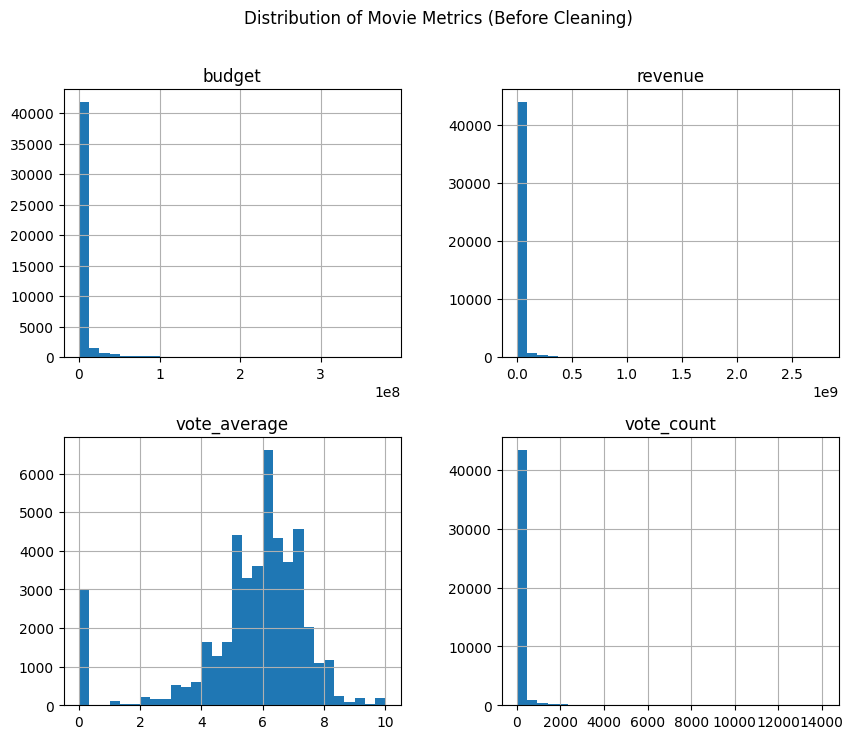

```python
movies[['budget','revenue', 'vote_average', 'vote_count']].hist(bins=30, figsize=(10, 8))
plt.suptitle('Distribution of Movie Metrics (Before Cleaning)')
plt.show()
```

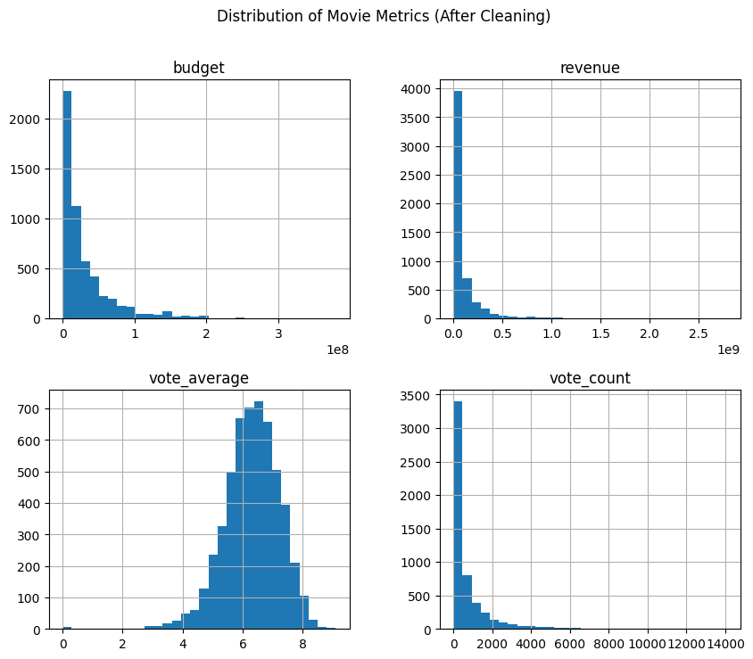

```python
movies = movies[(movies['budget']> 0) & (movies['revenue'] > 0)]

movies[['budget', 'revenue', 'vote_average', 'vote_count']].hist(bins=30, figsize=(10, 8))
plt.suptitle('Distribution of Movie Metrics (After Cleaning)')
plt.show()
```

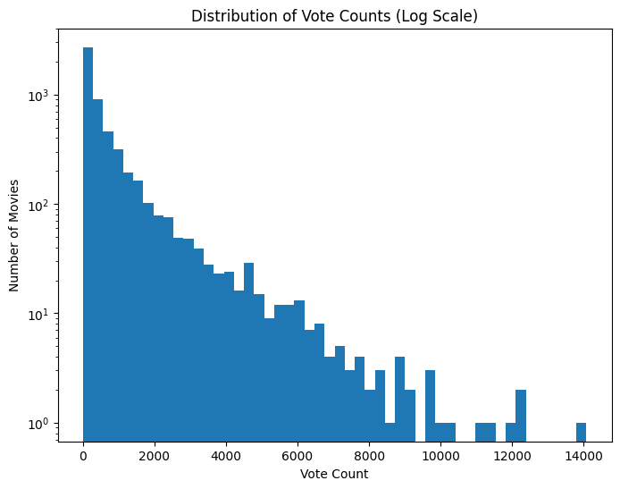

```python
plt.figure(figsize=(8, 6))
plt.hist(movies['vote_count'], bins=50, log=True)
plt.title('Distribution of Vote Counts (Log Scale)')
plt.xlabel('Vote Count')
plt.ylabel('Number of Movies')
plt.show()
```

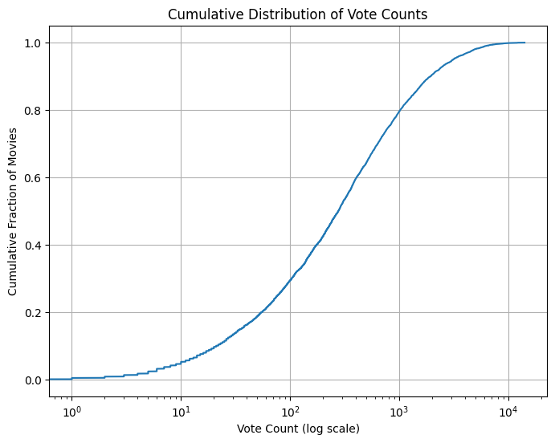

```python
plt.figure(figsize=(8, 6))
sorted_votes = np.sort(movies['vote_count'])
cumulative = np.arange(1, len(sorted_votes)+1) / len(sorted_votes)
plt.plot(sorted_votes, cumulative)
plt.xscale('log')
plt.title('Cumulative Distribution of Vote Counts')
plt.xlabel('Vote Count (log scale)')
plt.ylabel('Cumulative Fraction of Movies')
plt.grid(True)
plt.show()
```

# No Call backs for Extras

After reviewing the vote count distribution, I am applying a minimum threshold of 100 votes. Films with fewer than 100 votes tend to have unreliable or skewed ratings due to limited audience participation. Additionally, I am removing all entries lacking complete budget or revenue data, since those fields are required for financial comparison and ROI analysis.

```python
movies_clean = movies.copy()

movies_clean['budget'] = pd.to_numeric(movies_clean['budget'], errors='coerce')
movies_clean['revenue'] = pd.to_numeric(movies_clean['revenue'], errors='coerce')

movies_clean = movies_clean[
    (movies_clean['budget'] > 0) &
    (movies_clean['revenue'] > 0) &
    (movies_clean['vote_count'] >= 100)
]

movies_clean.shape
```

```
(3800, 5)
```

# Need Subtitles

Before clustering, I need to scale the numeric features. The values for budget and revenue are extremely large compared to vote_average and vote_count. If I feed these raw values into K-Means, the algorithm will focus almost entirely on the largest numbers and ignore the smaller ones.

To prevent this, I apply StandardScaler, which transforms each feature so that it has a mean of 0 and a standard deviation of 1. This puts all variables on the same scale, ensuring that each contributes equally to the clustering process.

```python
X = movies_clean[['budget', 'revenue', 'vote_average', 'vote_count']]

scaler = StandardScaler()
X_scaled = scaler.fit_transform(X)
```

# Lights......

To perform K-Means clustering, I need to choose a value for k, which is the number of clusters. However, the dataset doesn’t tell me what k should be. To determine this, I use the Elbow Method.

I calculate inertia for different values of k. Inertia is the sum of squared distances between each data point and its assigned cluster center. Lower inertia means tighter clusters. I then plot the inertia against k.

As k increases, inertia decreases — but only up to a point. Eventually, the decrease slows down and the plot begins to flatten. The point where the curve makes a noticeable bend, resembling an elbow, indicates a good balance between cluster accuracy and complexity.

This elbow point is the recommended choice for k because:

Smaller k values oversimplify and merge distinct patterns.

Larger k values add complexity without meaningful improvement.

In my case, the elbow appears around k = 4 to 5, so I select one of these values to proceed with clustering.

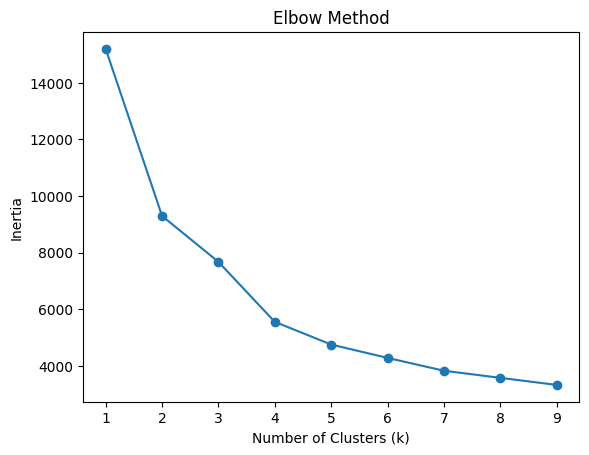

```python
inertia = []

for k in range(1, 10):
    km = KMeans(n_clusters=k, random_state=42)
    km.fit(X_scaled)
    inertia.append(km.inertia_)

plt.plot(range(1, 10), inertia, marker='o')
plt.xlabel('Number of Clusters (k)')
plt.ylabel('Inertia')
plt.title('Elbow Method')
plt.show()
```

# Camera!

Now that the optimal number of clusters has been chosen, I fit the K-Means model to the standardized feature data and assign each movie to a cluster. This adds a new column, cluster, indicating which group each movie belongs to. I then display the first 10 rows to verify that the clustering was applied correctly.

I chose K-Means because:

-The dataset is large, and K-Means handles large datasets efficiently. Agglomerative Clustering becomes computationally expensive as dataset size grows.

-K-Means produces clear, well-separated clusters when using numeric, scaled data, which fits this situation well.

-K-Means allows direct control over the number of clusters (k) and provides a measurable performance metric (inertia) used in the Elbow Method to justify the choice of k.

```python
kmeans = KMeans(n_clusters=4, random_state=42)
movies_clean['cluster'] = kmeans.fit_predict(X_scaled)

movies_clean[['title', 'budget', 'revenue', 'vote_average', 'vote_count', 'cluster']].head(10)
```

|  | title | budget | revenue | vote_average | vote_count | cluster |
| --- | --- | --- | --- | --- | --- | --- |
| 0 | Toy Story | 30000000.0 | 373554033.0 | 7.7 | 5415.0 | 2 |
| 1 | Jumanji | 65000000.0 | 262797249.0 | 6.9 | 2413.0 | 2 |
| 5 | Heat | 60000000.0 | 187436818.0 | 7.7 | 1886.0 | 3 |
| 8 | Sudden Death | 35000000.0 | 64350171.0 | 5.5 | 174.0 | 0 |
| 9 | GoldenEye | 58000000.0 | 352194034.0 | 6.6 | 1194.0 | 2 |
| 10 | The American President | 62000000.0 | 107879496.0 | 6.5 | 199.0 | 0 |
| 14 | Cutthroat Island | 98000000.0 | 10017322.0 | 5.7 | 137.0 | 0 |
| 15 | Casino | 52000000.0 | 116112375.0 | 7.8 | 1343.0 | 3 |
| 16 | Sense and Sensibility | 16500000.0 | 135000000.0 | 7.2 | 364.0 | 3 |
| 17 | Four Rooms | 4000000.0 | 4300000.0 | 6.5 | 539.0 | 3 |

# Places, PEOPLE!

To understand what makes each cluster distinct, I calculate the mean values of the features within each cluster. This summarizes the general characteristics of each group — for example, whether a cluster represents high-budget blockbusters, low-budget indie films, or critically well-received movies with moderate earnings.

```python
cluster_summary = movies_clean.groupby('cluster')[['budget','revenue','vote_average','vote_count']].mean()
cluster_summary
```

| cluster | budget | revenue | vote_average | vote_count |
| --- | --- | --- | --- | --- |
| 0 | 3.191731e+07 | 6.305902e+07 | 5.648425 | 431.069863 |
| 1 | 1.486522e+08 | 7.702420e+08 | 7.145062 | 5743.691358 |
| 2 | 9.754014e+07 | 2.844349e+08 | 6.345714 | 1962.862857 |
| 3 | 1.793371e+07 | 6.091134e+07 | 7.023351 | 778.327284 |

# Cinematography

To see how the movies are grouped, I reduce the dataset’s dimensions using Principal Component Analysis (PCA) and plot the clusters in a 2-D space. PCA keeps the most important variance in the data while allowing the clusters to be visualized clearly. This visual helps reveal how distinct the clusters are and whether any groups overlap.

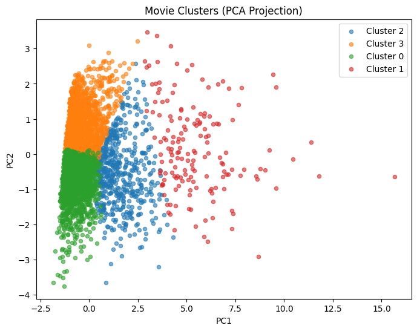

```python
pca = PCA(n_components=2)
X_pca = pca.fit_transform(X_scaled)

movies_clean['pc1'] = X_pca[:, 0]
movies_clean['pc2'] = X_pca[:, 1]

plt.figure(figsize=(8,6))
for c in movies_clean['cluster'].unique():
    cluster_data = movies_clean[movies_clean['cluster'] == c]
    plt.scatter(cluster_data['pc1'], cluster_data['pc2'], s=20, label=f'Cluster {c}', alpha=0.6)

plt.xlabel('PC1')
plt.ylabel('PC2')
plt.title('Movie Clusters (PCA Projection)')
plt.legend()
plt.show()
```

# Action!

This heatmap highlights the differences between clusters by showing the average feature values within each group. It makes it easy to see which clusters tend to have higher budgets, greater revenues, or stronger audience ratings, giving us a quick visual summary of what characterizes each cluster.

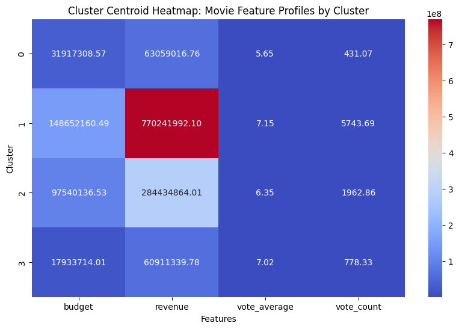

```python
features = ['budget', 'revenue', 'vote_average', 'vote_count']

cluster_centroids = movies_clean.groupby('cluster')[features].mean()

plt.figure(figsize=(10, 6))
sns.heatmap(cluster_centroids, annot=True, cmap='coolwarm', fmt='.2f')
plt.title("Cluster Centroid Heatmap: Movie Feature Profiles by Cluster")
plt.xlabel("Features")
plt.ylabel("Cluster")
plt.show()
```

# The Reviews are In!

The heatmap allows us to compare how each cluster behaves across budget, revenue, audience ratings, and vote counts (audience engagement). A clear pattern emerges: films with higher budgets tend to show higher audience engagement and, in some cases, better average ratings. This makes sense — larger budgets often mean wider releases, more marketing, and more visibility, which increases the number of votes.

This suggests that:

Spending more money helps a movie get seen, but does not guarantee audience satisfaction.

There may be a threshold where increasing budget (and therefore revenue potential) no longer improves audience perception — possibly because marketing hype can drive people to theaters, but cannot force them to like the movie.

# Impact

This analysis suggests that there are budget thresholds where increases in spending lead to higher audience engagement and visibility. In other words, larger budgets tend to correlate with higher revenue and more audience interaction, likely because higher-budget films receive wider releases and stronger marketing campaigns. However, this does not mean that high budget automatically results in a better film — it only increases the likelihood that more people will see the film and rate it. The data implies that success follows attention, not necessarily quality.

However, we need to be careful about how this insight is interpreted. If studios rely too heavily on patterns like this, it could reinforce a cycle where only high-budget productions are considered “worth” making, potentially pushing out smaller or independent films that don’t have the same financial backing. This creates a cultural cost: fewer risks, fewer new voices, and fewer stories outside the mainstream.

This project is also limited by the dataset itself. Although the original dataset contained over 45,000 entries, most were unusable because of missing or incomplete financial information. The conclusions drawn here are based on the much smaller subset of ~3,800 films that reported full data. It’s also worth noting that the dataset doesn’t separate production budget from marketing spend, which is often a major factor in visibility and engagement. Without that, the analysis can only point to correlations, not causes.

In short:

We can say: Higher budgets tend to increase audience engagement and revenue.

We cannot say: Higher budgets make better movies.

The project provides insight into how financial scale influences audience reach, but a complete answer to what makes a film successful would require additional data — including marketing, genre, distribution scope, and cultural context.

# References

Banik, R. (n.d.). The Movies Dataset [Data set].  
Kaggle. https://www.kaggle.com/datasets/rounakbanik/the-movies-dataset

OpenAI. (2025).ChatGPT[Large language model].OpenAI.  
https://chat.openai.com

# Disclaimer

Portions of the code refinement, data exploration, and narrative structuring were assisted by OpenAI’s ChatGPT (GPT-5). I directed the analysis, made final decisions on preprocessing steps, and selected visualizations, while ChatGPT was used as a learning and drafting tool.